# Random Slopes: When to Add and How to Interpret

Beyond Random Intercepts in Mixed Models

## 1. Random Intercepts vs Random Slopes

### Conceptual Distinction

**Random Intercepts Only (RI):**

- All subjects share the *same* slope (rate of change over time)
- Subjects differ only in their starting points (baseline values)
- The trajectories are parallel lines shifted vertically

**Random Intercepts + Random Slopes (RI + RS):**

- Subjects have *different* slopes AND different starting points
- Each subject has their own trajectory
- Lines can cross each other—not parallel

### Visual Comparison

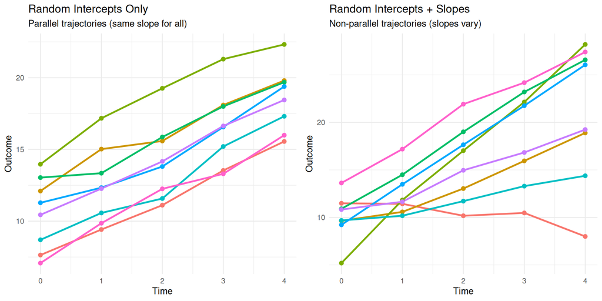

Figure 1: Comparison of Random Intercept Only vs Random Intercept + Slope Models

```r
# Simulate data for visualization
n_subj <- 8
n_time <- 5
time_points <- 0:4

# Random intercepts only (parallel lines)
ri_data <- data.frame(
  id = rep(1:n_subj, each = n_time),
  time = rep(time_points, n_subj)
)
ri_intercepts <- rnorm(n_subj, mean = 10, sd = 3)
ri_data$y <- ri_intercepts[ri_data$id] + 2 * ri_data$time + rnorm(n_subj * n_time, 0, 0.5)

# Random intercepts + slopes (non-parallel lines)
rs_data <- data.frame(
  id = rep(1:n_subj, each = n_time),
  time = rep(time_points, n_subj)
)
rs_intercepts <- rnorm(n_subj, mean = 10, sd = 3)
rs_slopes <- rnorm(n_subj, mean = 2, sd = 1.5)  # Slopes vary!
rs_data$y <- rs_intercepts[rs_data$id] + rs_slopes[rs_data$id] * rs_data$time +
             rnorm(n_subj * n_time, 0, 0.5)

# Create plots
p1 <- ggplot(ri_data, aes(x = time, y = y, group = factor(id), color = factor(id))) +
  geom_line(linewidth = 1) +
  geom_point(size = 2) +
  labs(title = "Random Intercepts Only",
       subtitle = "Parallel trajectories (same slope for all)",
       x = "Time", y = "Outcome") +
  theme_minimal() +
  theme(legend.position = "none")

p2 <- ggplot(rs_data, aes(x = time, y = y, group = factor(id), color = factor(id))) +
  geom_line(linewidth = 1) +
  geom_point(size = 2) +
  labs(title = "Random Intercepts + Slopes",
       subtitle = "Non-parallel trajectories (slopes vary)",
       x = "Time", y = "Outcome") +
  theme_minimal() +
  theme(legend.position = "none")

grid.arrange(p1, p2, ncol = 2)
```

**Key Insight:** In the left panel, subjects start at different places but change at the same rate. In the right panel, subjects both start differently AND change at different rates—some increase quickly, others slowly, and some may even decrease.

## 2. When to Add Random Slopes

Use the following diagnostic signals to decide whether random slopes are needed:

| Signal | What it Means | Action |
| --- | --- | --- |
| **Fanning pattern** in residuals vs time | Subject-level heterogeneity in slopes | Add random slope for time |
| **Theoretical expectation** of varying trajectories | Domain knowledge suggests individual variation | Include random slope a priori |
| **Significant LRT** comparing RI vs RI+RS | Random slope improves model fit | Retain the random slope |
| **Random slope variance** significantly > 0 | Meaningful between-subject variability in slopes | Keep the random slope |
| **Spaghetti plot** shows crossing/diverging lines | Visual evidence of slope heterogeneity | Strong candidate for random slope |

### Decision Framework

1. **Plot individual trajectories** (spaghetti plot)
   - Do lines cross or fan out? Consider random slopes
2. **Fit RI-only model**, examine residuals vs time
   - Fanning pattern present? Add random slopes
3. **Compare RI vs RI+RS models** via LRT (use ML, not REML)
   - Significant improvement? Keep random slopes
4. **Check if model converges** with random slopes
   - Convergence issues? May need simpler structure

## 3. The Model

### Mathematical Specification

The linear mixed model with random intercepts and slopes is:

$$Y_{ij} = (\beta_0 + b_{0i}) + (\beta_1 + b_{1i}) \cdot \text{time}_{ij} + \varepsilon_{ij}$$

Where:

- $Y_{ij}$ = outcome for subject $i$ at time $j$
- $\beta_0$ = population-average intercept (mean at time = 0)
- $\beta_1$ = population-average slope (mean rate of change)
- $b_{0i}$ = subject-specific deviation from population intercept
- $b_{1i}$ = subject-specific deviation from population slope
- $\varepsilon_{ij}$ = residual error

### Random Effects Distribution

The random effects follow a multivariate normal distribution:

$$\begin{pmatrix} b_{0i} \\ b_{1i} \end{pmatrix} \sim \text{MVN}\left( \begin{pmatrix} 0 \\ 0 \end{pmatrix}, \mathbf{D} \right)$$

Where the variance-covariance matrix is:

$$\mathbf{D} = \begin{pmatrix} \sigma^2_{b_0} & \sigma_{b_{01}} \\ \sigma_{b_{01}} & \sigma^2_{b_1} \end{pmatrix}$$

### Interpreting the Correlation

The correlation between random intercepts and slopes:

$$\rho_{01} = \frac{\sigma_{b_{01}}}{\sigma_{b_0} \cdot \sigma_{b_1}}$$

| Correlation | Interpretation |
| --- | --- |
| $\rho_{01} > 0$ (positive) | Subjects who start higher tend to increase faster |
| $\rho_{01} < 0$ (negative) | Subjects who start higher tend to increase slower (regression to mean) |
| $\rho_{01} \approx 0$ | Starting point and rate of change are independent |

**Example:** In growth studies, negative correlation often occurs—children who are taller at baseline tend to grow more slowly (they’re closer to their adult height).

## 4. Variance Components Interpretation

| Parameter | Symbol | Interpretation |
| --- | --- | --- |
| Random intercept variance | $\sigma^2_{b_0}$ | Between-subject variance **at time = 0**; how much subjects differ at baseline |
| Random slope variance | $\sigma^2_{b_1}$ | Between-subject variance **in rates of change**; how much slopes vary across subjects |
| Covariance | $\sigma_{b_{01}}$ | Association between starting point and rate of change |
| Correlation | $\rho_{01}$ | Standardized covariance (bounded -1 to 1) |
| Residual variance | $\sigma^2$ | Within-subject variance not explained by random effects |

### Important Note on Centering

**The interpretation of $\sigma^2_{b_0}$ depends on how time is coded:**

- If `time` starts at 0: $\sigma^2_{b_0}$ = variance at baseline
- If `time` is centered at the mean: $\sigma^2_{b_0}$ = variance at the mean time point
- This also affects the intercept-slope covariance!

**Recommendation:** Always think carefully about centering time to make variance components interpretable.

## 5. R Code Syntax

### Package Comparison

**Random intercept only:**

- nlme: `random = ~1|id`
- lme4: `(1|id)`

**Random intercept + slope:**

- nlme: `random = ~time|id`
- lme4: `(1 + time|id)`

**Random slope only** (rare):

- nlme: `random = ~0 + time|id`
- lme4: `(0 + time|id)`

**Uncorrelated RI + RS:**

- nlme: `random = list(id = pdDiag(~time))`
- lme4: `(1|id) + (0 + time|id)`

### nlme Examples

```r
# Random intercept only
fit_ri <- lme(y ~ time + treatment,
              random = ~1|id,
              data = mydata)

# Random intercept + slope (correlated)
fit_rs <- lme(y ~ time + treatment,
              random = ~time|id,
              data = mydata)

# Random intercept + slope (uncorrelated - diagonal D matrix)
fit_rs_uncor <- lme(y ~ time + treatment,
                    random = list(id = pdDiag(~time)),
                    data = mydata)
```

### lme4 Examples

```r
# Random intercept only
fit_ri <- lmer(y ~ time + treatment + (1|id), data = mydata)

# Random intercept + slope (correlated)
fit_rs <- lmer(y ~ time + treatment + (1 + time|id), data = mydata)

# Random intercept + slope (uncorrelated)
fit_rs_uncor <- lmer(y ~ time + treatment + (1|id) + (0 + time|id), data = mydata)
```

### Extracting Variance Components

```r
# nlme
VarCorr(fit_rs)  # Shows variances and correlations
intervals(fit_rs)  # Confidence intervals

# lme4
VarCorr(fit_rs)  # Shows variances and correlations
as.data.frame(VarCorr(fit_rs))  # As a data frame
confint(fit_rs, oldNames = FALSE)  # Profile likelihood CIs
```

## 6. Diagnostic Check: The Fanning Pattern

The “fanning pattern” is a key diagnostic for detecting the need for random slopes.

### What to Look For

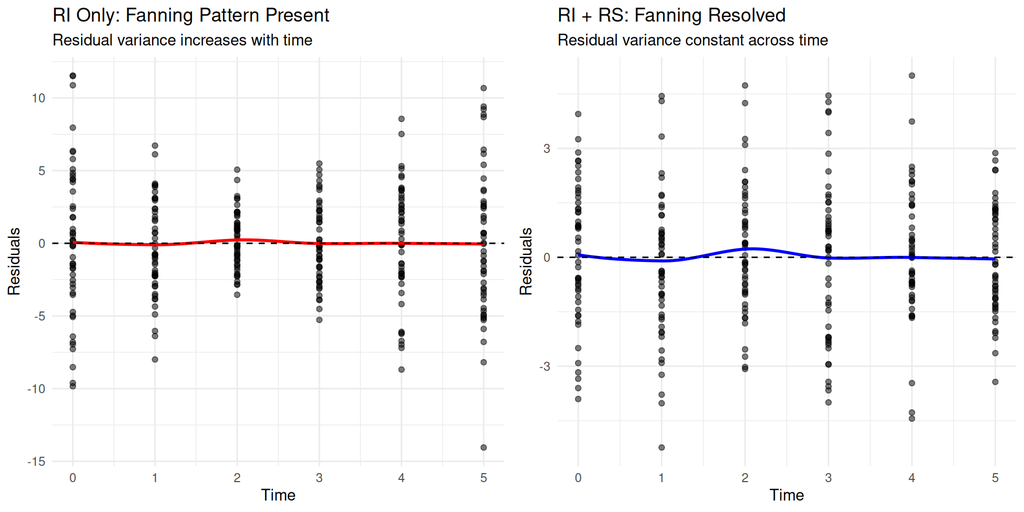

Figure 2: Detecting the Fanning Pattern in Residuals

```r
# Simulate data with heterogeneous slopes
n_subj <- 50
n_time <- 6

sim_data <- data.frame(
  id = rep(1:n_subj, each = n_time),
  time = rep(0:(n_time-1), n_subj)
)

# True model has random slopes
true_int <- rnorm(n_subj, 50, 5)
true_slope <- rnorm(n_subj, 3, 2)  # Substantial slope variability
sim_data$y <- true_int[sim_data$id] + true_slope[sim_data$id] * sim_data$time +
              rnorm(n_subj * n_time, 0, 2)

# Fit RI-only model (misspecified)
fit_ri_wrong <- lme(y ~ time, random = ~1|id, data = sim_data)

# Fit correct RI+RS model
fit_rs_correct <- lme(y ~ time, random = ~time|id, data = sim_data)

# Get residuals
sim_data$resid_ri <- residuals(fit_ri_wrong)
sim_data$resid_rs <- residuals(fit_rs_correct)

# Plot residuals
p1 <- ggplot(sim_data, aes(x = time, y = resid_ri)) +
  geom_point(alpha = 0.5) +
  geom_smooth(method = "loess", se = FALSE, color = "red") +
  geom_hline(yintercept = 0, linetype = "dashed") +
  labs(title = "RI Only: Fanning Pattern Present",
       subtitle = "Residual variance increases with time",
       x = "Time", y = "Residuals") +
  theme_minimal()

p2 <- ggplot(sim_data, aes(x = time, y = resid_rs)) +
  geom_point(alpha = 0.5) +
  geom_smooth(method = "loess", se = FALSE, color = "blue") +
  geom_hline(yintercept = 0, linetype = "dashed") +
  labs(title = "RI + RS: Fanning Resolved",
       subtitle = "Residual variance constant across time",
       x = "Time", y = "Residuals") +
  theme_minimal()

grid.arrange(p1, p2, ncol = 2)
```

### Interpreting the Pattern

**Right panel (RI + RS):** After adding random slopes, the residuals show constant variance across time. The fanning disappears because subject-specific slopes are now modeled.

## 7. Boundary Tests for Variance Components

### The Problem

When testing whether a random slope is needed:

$$H_0: \sigma^2_{b_1} = 0 \quad \text{vs} \quad H_1: \sigma^2_{b_1} > 0$$

The null hypothesis places the parameter on the boundary of the parameter space (variance cannot be negative). This violates standard LRT assumptions.

### The Solution: Mixture Chi-Square Distribution

Under the null, the LRT statistic follows a **mixture of chi-square distributions**, not a standard chi-square.

For testing one variance component:

$$\text{LRT} \sim 0.5 \cdot \chi^2_0 + 0.5 \cdot \chi^2_1$$

This means the p-value from a standard `anova()` is **conservative** (too large).

### Practical Approaches

**Option 1: Divide the p-value by 2**

```r
# Compare RI vs RI+RS models (must use ML, not REML!)
fit_ri_ml <- lme(y ~ time, random = ~1|id, data = mydata, method = "ML")
fit_rs_ml <- lme(y ~ time, random = ~time|id, data = mydata, method = "ML")

lrt_result <- anova(fit_ri_ml, fit_rs_ml)
corrected_pvalue <- lrt_result$`p-value`[2] / 2
```

**Option 2: Use the exact mixture distribution**

For adding both a variance and covariance (2 parameters):

$$\text{LRT} \sim 0.5 \cdot \chi^2_1 + 0.5 \cdot \chi^2_2$$

```r
# Critical value for mixture (alpha = 0.05)
# P(0.5*chi2_1 + 0.5*chi2_2 > cv) = 0.05
# Approximately cv = 5.14 for 2 df case

lrt_stat <- -2 * (logLik(fit_ri_ml) - logLik(fit_rs_ml))
pval_mixture <- 0.5 * pchisq(lrt_stat, df = 1, lower.tail = FALSE) +
                0.5 * pchisq(lrt_stat, df = 2, lower.tail = FALSE)
```

### Important Reminder

**Always use ML (not REML) when comparing models with different fixed OR random effects structures via LRT.**

```r
# WRONG: Using REML for model comparison
fit1 <- lme(y ~ time, random = ~1|id, data = mydata)  # REML is default
fit2 <- lme(y ~ time, random = ~time|id, data = mydata)
anova(fit1, fit2)  # Invalid comparison!

# CORRECT: Use ML
fit1_ml <- lme(y ~ time, random = ~1|id, data = mydata, method = "ML")
fit2_ml <- lme(y ~ time, random = ~time|id, data = mydata, method = "ML")
anova(fit1_ml, fit2_ml)  # Valid comparison
```

## 8. BLUPs for Subject-Specific Predictions

### What are BLUPs?

**BLUP** = Best Linear Unbiased Predictor

BLUPs provide estimates of the subject-specific random effects ($b_{0i}$, $b_{1i}$). They are “predictions” rather than “estimates” because random effects are random variables, not fixed parameters.

### Key Properties

1. **Shrinkage:** BLUPs are “shrunk” toward zero (the population mean of random effects)
2. **Reliability-weighted:** Subjects with more observations or less noise get BLUPs closer to their empirical values
3. **Borrowing strength:** Information from all subjects informs each individual’s BLUP

### Extracting BLUPs in R

```r
# nlme
ranef(fit_rs)           # Random effects (deviations from population)
coef(fit_rs)            # Subject-specific coefficients (β + b)

# lme4
ranef(fit_rs)           # Random effects
coef(fit_rs)$id         # Subject-specific coefficients
```

### Predictions: Population vs Subject-Specific

```r
# nlme predictions
predict(fit_rs, level = 0)  # Population-average (fixed effects only)
predict(fit_rs, level = 1)  # Subject-specific (fixed + random effects)

# lme4 predictions
predict(fit_rs, re.form = NA)   # Population-average
predict(fit_rs, re.form = NULL) # Subject-specific (default)
```

| Level | What it Gives | Use Case |
| --- | --- | --- |
| `level = 0` / `re.form = NA` | $\hat{Y} = \hat{\beta}_0 + \hat{\beta}_1 \cdot \text{time}$ | Population-average trajectory |
| `level = 1` / `re.form = NULL` | $\hat{Y} = (\hat{\beta}_0 + \hat{b}_{0i}) + (\hat{\beta}_1 + \hat{b}_{1i}) \cdot \text{time}$ | Individual predictions |

### Visualizing Shrinkage

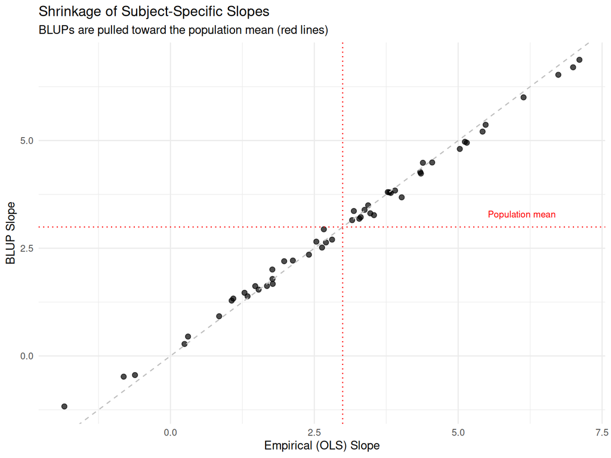

Figure 3: BLUP Shrinkage: Subject-Specific Estimates Pulled Toward Population Mean

```r
# Using the earlier simulated data
blups <- ranef(fit_rs_correct)

# Calculate empirical (OLS) slopes for each subject
empirical_slopes <- sim_data %>%
  group_by(id) %>%
  summarize(
    ols_slope = coef(lm(y ~ time))[2],
    n_obs = n()
  )

# Compare to BLUPs
comparison <- data.frame(
  id = 1:n_subj,
  ols_slope = empirical_slopes$ols_slope,
  blup_slope = fixef(fit_rs_correct)["time"] + blups$time
)

# Population mean slope
pop_slope <- fixef(fit_rs_correct)["time"]

ggplot(comparison, aes(x = ols_slope, y = blup_slope)) +
  geom_point(size = 2, alpha = 0.7) +
  geom_abline(slope = 1, intercept = 0, linetype = "dashed", color = "gray") +
  geom_hline(yintercept = pop_slope, color = "red", linetype = "dotted") +
  geom_vline(xintercept = pop_slope, color = "red", linetype = "dotted") +
  labs(title = "Shrinkage of Subject-Specific Slopes",
       subtitle = "BLUPs are pulled toward the population mean (red lines)",
       x = "Empirical (OLS) Slope",
       y = "BLUP Slope") +
  theme_minimal() +
  annotate("text", x = max(comparison$ols_slope) - 1, y = pop_slope + 0.3,
           label = "Population mean", color = "red", size = 3)
```

**Interpretation:** Points lie between the 45-degree line (no shrinkage) and the population mean (complete shrinkage). Extreme OLS estimates are pulled more strongly toward the mean.

## 9. Worked Example

### The Data: Longitudinal Growth Study

We’ll simulate a growth study where children are measured at multiple time points. We expect individual variation in both baseline height and growth rates.

```r
set.seed(667)

# Simulation parameters
n_children <- 40
n_visits <- 5
ages <- c(6, 7, 8, 9, 10)  # Ages 6-10

# Generate data
growth_data <- data.frame(
  child_id = rep(1:n_children, each = n_visits),
  age = rep(ages, n_children)
)

# True parameters
beta0 <- 110     # Mean height at age 6
beta1 <- 5       # Mean growth rate (cm/year)
sigma_b0 <- 6    # SD of random intercepts
sigma_b1 <- 1.2  # SD of random slopes
rho <- -0.4      # Correlation (taller kids grow slower)
sigma_e <- 1.5   # Residual SD

# Generate correlated random effects
library(MASS)
D <- matrix(c(sigma_b0^2, rho*sigma_b0*sigma_b1,
              rho*sigma_b0*sigma_b1, sigma_b1^2), nrow = 2)
random_effects <- mvrnorm(n_children, mu = c(0, 0), Sigma = D)

# Center age at 6 (baseline)
growth_data$age_c <- growth_data$age - 6

# Generate outcomes
growth_data$height <- beta0 + random_effects[growth_data$child_id, 1] +
                      (beta1 + random_effects[growth_data$child_id, 2]) * growth_data$age_c +
                      rnorm(n_children * n_visits, 0, sigma_e)

head(growth_data, 10)
```

```
   child_id age age_c   height
1         1   6     0 113.0017
2         1   7     1 119.5646
3         1   8     2 125.1790
4         1   9     3 128.3508
5         1  10     4 133.1958
6         2   6     0 103.5371
7         2   7     1 108.3284
8         2   8     2 113.2526
9         2   9     3 116.7014
10        2  10     4 119.9623
```

### Step 1: Visualize the Data

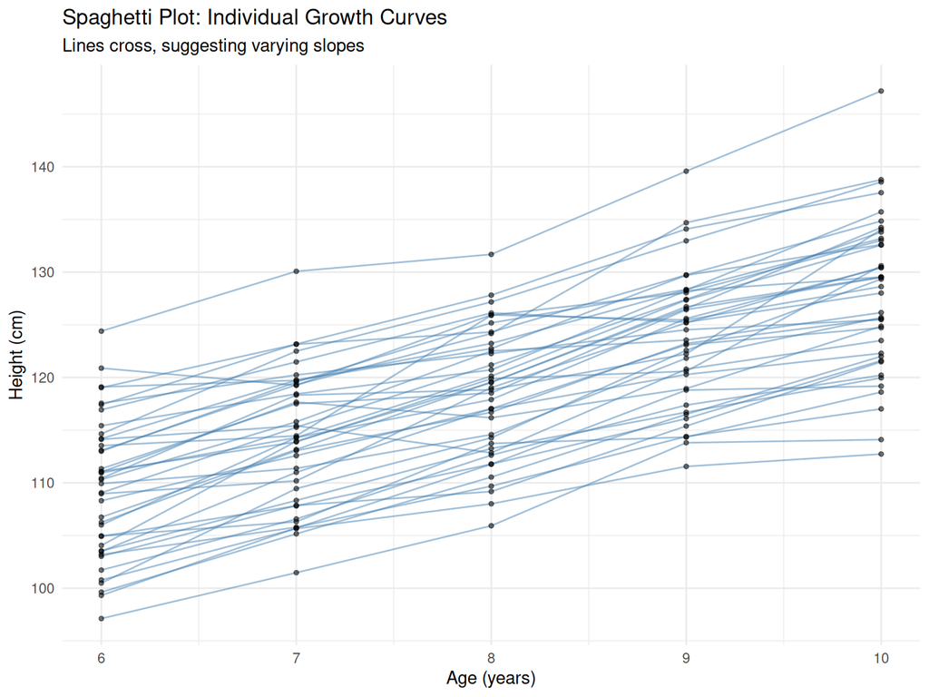

Figure 4: Individual Growth Trajectories

```r
ggplot(growth_data, aes(x = age, y = height, group = child_id)) +
  geom_line(alpha = 0.5, color = "steelblue") +
  geom_point(alpha = 0.5, size = 1) +
  labs(title = "Spaghetti Plot: Individual Growth Curves",
       subtitle = "Lines cross, suggesting varying slopes",
       x = "Age (years)", y = "Height (cm)") +
  theme_minimal()
```

**Observation:** The trajectories are not parallel—lines cross each other, suggesting children grow at different rates.

### Step 2: Fit Random Intercept Only Model

```r
# Random intercept only
fit_ri <- lme(height ~ age_c,
              random = ~1|child_id,
              data = growth_data)

summary(fit_ri)
```

```
Linear mixed-effects model fit by REML
  Data: growth_data
       AIC      BIC    logLik
  1073.708 1086.861 -532.8542

Random effects:
 Formula: ~1 | child_id
        (Intercept) Residual
StdDev:    6.041626 2.474864

Fixed effects:  height ~ age_c
                Value Std.Error  DF   t-value p-value
(Intercept) 109.50114 1.0022003 159 109.26074       0
age_c         4.62966 0.1237432 159  37.41342       0
 Correlation:
      (Intr)
age_c -0.247

Standardized Within-Group Residuals:
        Min          Q1         Med          Q3         Max
-2.29599474 -0.52616887 -0.02727195  0.61529144  2.53983997

Number of Observations: 200
Number of Groups: 40
```

### Step 3: Check for Fanning Pattern

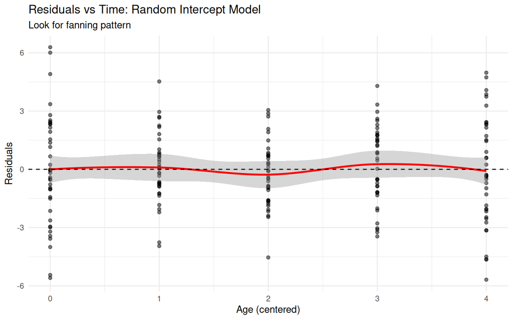

Figure 5: Residual Diagnostics for RI Model

```r
growth_data$resid_ri <- residuals(fit_ri)

ggplot(growth_data, aes(x = age_c, y = resid_ri)) +
  geom_point(alpha = 0.5) +
  geom_smooth(method = "loess", se = TRUE, color = "red") +
  geom_hline(yintercept = 0, linetype = "dashed") +
  labs(title = "Residuals vs Time: Random Intercept Model",
       subtitle = "Look for fanning pattern",
       x = "Age (centered)", y = "Residuals") +
  theme_minimal()
```

### Step 4: Fit Random Intercept + Slope Model

```r
# Random intercept + slope
fit_rs <- lme(height ~ age_c,
              random = ~age_c|child_id,
              data = growth_data)

summary(fit_rs)
```

```
Linear mixed-effects model fit by REML
  Data: growth_data
       AIC      BIC   logLik
  1021.502 1041.232 -504.751

Random effects:
 Formula: ~age_c | child_id
 Structure: General positive-definite, Log-Cholesky parametrization
            StdDev   Corr
(Intercept) 6.209339 (Intr)
age_c       1.163963 -0.236
Residual    1.673867

Fixed effects:  height ~ age_c
                Value Std.Error  DF   t-value p-value
(Intercept) 109.50114 1.0029580 159 109.17820       0
age_c         4.62966 0.2021752 159  22.89923       0
 Correlation:
      (Intr)
age_c -0.279

Standardized Within-Group Residuals:
         Min           Q1          Med           Q3          Max
-2.684246034 -0.483580704  0.002867238  0.504326388  1.923026263

Number of Observations: 200
Number of Groups: 40
```

### Step 5: Compare Variance Components

```r
# Extract variance components
cat("=== Random Intercept Only ===\n")
```

```
=== Random Intercept Only ===
```

```r
VarCorr(fit_ri)
```

```
child_id = pdLogChol(1)
            Variance  StdDev
(Intercept) 36.501244 6.041626
Residual     6.124952 2.474864
```

```r
cat("\n=== Random Intercept + Slope ===\n")
```

```
=== Random Intercept + Slope ===
```

```r
VarCorr(fit_rs)
```

```
child_id = pdLogChol(age_c)
            Variance  StdDev   Corr
(Intercept) 38.555888 6.209339 (Intr)
age_c        1.354809 1.163963 -0.236
Residual     2.801832 1.673867
```

**Interpretation of RI+RS variance components:**

- **Random intercept SD:** Variation in height at baseline (age 6)
- **Random slope SD:** Variation in growth rates across children
- **Correlation:** Negative correlation suggests taller children at baseline grow more slowly

### Step 6: Model Comparison via LRT

```r
# Must use ML for valid LRT
fit_ri_ml <- lme(height ~ age_c, random = ~1|child_id,
                 data = growth_data, method = "ML")
fit_rs_ml <- lme(height ~ age_c, random = ~age_c|child_id,
                 data = growth_data, method = "ML")

# LRT
lrt <- anova(fit_ri_ml, fit_rs_ml)
print(lrt)
```

```
          Model df      AIC      BIC    logLik   Test  L.Ratio p-value
fit_ri_ml     1  4 1073.131 1086.324 -532.5653
fit_rs_ml     2  6 1021.880 1041.670 -504.9400 1 vs 2 55.25065  <.0001
```

```r
# Corrected p-value for boundary test (conservative)
cat("\nCorrected p-value (boundary adjustment):",
    lrt$`p-value`[2] / 2, "\n")
```

```
Corrected p-value (boundary adjustment): 5.028561e-13
```

### Step 7: Check Residuals After Adding Random Slopes

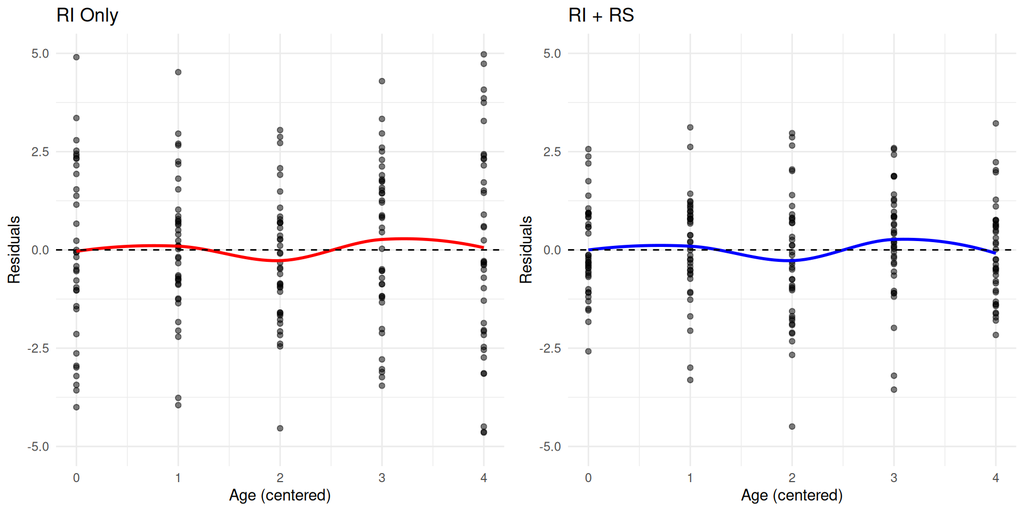

Figure 6: Residual Comparison: Before and After Adding Random Slopes

```r
growth_data$resid_rs <- residuals(fit_rs)

p1 <- ggplot(growth_data, aes(x = age_c, y = resid_ri)) +
  geom_point(alpha = 0.5) +
  geom_smooth(method = "loess", se = FALSE, color = "red") +
  geom_hline(yintercept = 0, linetype = "dashed") +
  ylim(c(-5, 5)) +
  labs(title = "RI Only", x = "Age (centered)", y = "Residuals") +
  theme_minimal()

p2 <- ggplot(growth_data, aes(x = age_c, y = resid_rs)) +
  geom_point(alpha = 0.5) +
  geom_smooth(method = "loess", se = FALSE, color = "blue") +
  geom_hline(yintercept = 0, linetype = "dashed") +
  ylim(c(-5, 5)) +
  labs(title = "RI + RS", x = "Age (centered)", y = "Residuals") +
  theme_minimal()

grid.arrange(p1, p2, ncol = 2)
```

### Step 8: Extract and Plot BLUPs

```r
# Get BLUPs
blups <- ranef(fit_rs)
head(blups)
```

```
  (Intercept)      age_c
1   4.5008808  0.2613601
2  -5.4147064 -0.4487043
3  -9.4067620  0.7721293
4  -2.8619914  1.4378204
5   1.1684314  0.4093056
6  -0.8544721 -0.8881226
```

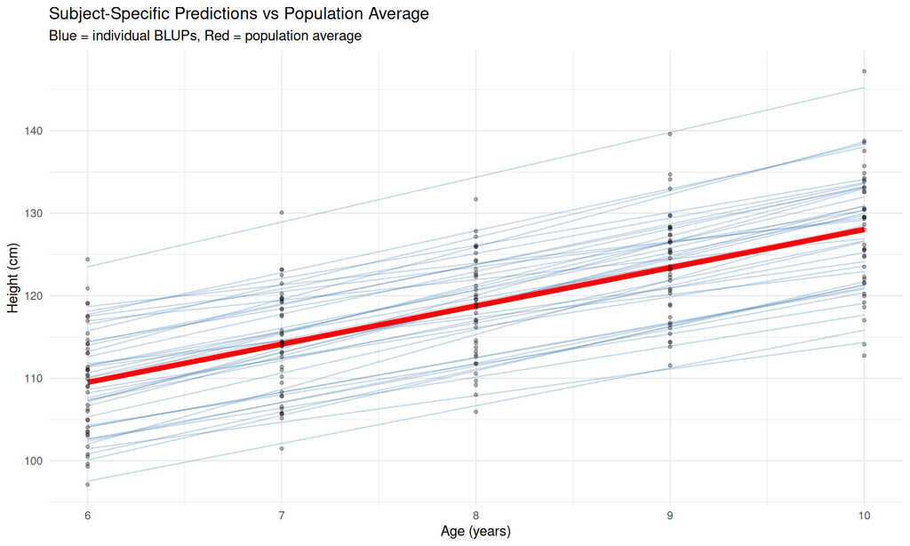

Figure 7: Subject-Specific Predictions from BLUPs

```r
# Create prediction data
pred_data <- expand.grid(
  child_id = unique(growth_data$child_id),
  age_c = seq(0, 4, by = 0.5)
)
pred_data$age <- pred_data$age_c + 6

# Population average prediction
pred_data$pop_pred <- predict(fit_rs, newdata = pred_data, level = 0)

# Subject-specific predictions
pred_data$subj_pred <- predict(fit_rs, newdata = pred_data, level = 1)

# Plot
ggplot() +
  # Subject-specific predictions
  geom_line(data = pred_data,
            aes(x = age, y = subj_pred, group = child_id),
            alpha = 0.3, color = "steelblue") +
  # Population average
  geom_line(data = pred_data[pred_data$child_id == 1, ],
            aes(x = age, y = pop_pred),
            color = "red", linewidth = 2) +
  # Observed data
  geom_point(data = growth_data,
             aes(x = age, y = height),
             alpha = 0.3, size = 1) +
  labs(title = "Subject-Specific Predictions vs Population Average",
       subtitle = "Blue = individual BLUPs, Red = population average",
       x = "Age (years)", y = "Height (cm)") +
  theme_minimal()
```

### Step 9: Examine Intercept-Slope Correlation

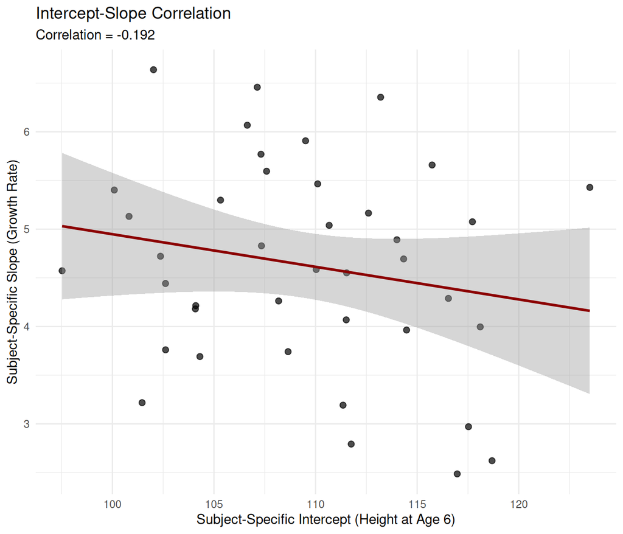

Figure 8: Correlation Between Random Intercepts and Slopes

```r
# Extract subject-specific coefficients
subj_coef <- coef(fit_rs)

ggplot(subj_coef, aes(x = `(Intercept)`, y = age_c)) +
  geom_point(size = 2, alpha = 0.7) +
  geom_smooth(method = "lm", se = TRUE, color = "darkred") +
  labs(title = "Intercept-Slope Correlation",
       subtitle = paste("Correlation =", round(cor(subj_coef$`(Intercept)`, subj_coef$age_c), 3)),
       x = "Subject-Specific Intercept (Height at Age 6)",
       y = "Subject-Specific Slope (Growth Rate)") +
  theme_minimal()
```

**Interpretation:** The negative correlation indicates that children who are taller at age 6 tend to grow more slowly—consistent with the idea that they are closer to their adult height.

## 10. Common Mistakes

### Mistake 1: Adding Too Many Random Effects

**Problem:** Including random slopes for every predictor leads to convergence issues.

```r
# Problematic: Too complex random effects structure
fit_overfit <- lmer(y ~ time * treatment + (1 + time + treatment + time:treatment | id),
                    data = mydata)
# Often fails to converge or produces singular fits
```

**Solution:** Start simple, add complexity only when justified by data and theory.

### Mistake 2: Not Centering Time

**Problem:** When time doesn’t start at 0, the random intercept variance may not be interpretable.

```r
# Example: time measured as years 2020, 2021, 2022...
# Random intercept variance would be at "year 0" (meaningless!)

# Better: Center time at baseline
# growth_data$time_c <- growth_data$year - min(growth_data$year)
```

**Solution:** Center time at a meaningful reference point (usually baseline).

### Mistake 3: Ignoring the Intercept-Slope Correlation

**Problem:** Forcing uncorrelated random effects when correlation exists.

```r
# Forces zero correlation (may be inappropriate)
fit_uncor <- lmer(y ~ time + (1|id) + (0 + time|id), data = mydata)

# Allows correlation (usually preferred unless theory suggests otherwise)
fit_cor <- lmer(y ~ time + (1 + time|id), data = mydata)
```

**Solution:** Generally allow correlation unless you have strong theoretical reasons not to.

### Mistake 4: Using LRT with REML

**Problem:** REML likelihoods are not comparable across models with different fixed effects.

```r
# WRONG
fit1 <- lme(y ~ time, random = ~1|id, data = mydata)  # REML default
fit2 <- lme(y ~ time, random = ~time|id, data = mydata)
anova(fit1, fit2)  # Invalid!

# CORRECT
fit1_ml <- lme(y ~ time, random = ~1|id, data = mydata, method = "ML")
fit2_ml <- lme(y ~ time, random = ~time|id, data = mydata, method = "ML")
anova(fit1_ml, fit2_ml)  # Valid
```

**Rule:** Use ML for model comparison, REML for final parameter estimation.

## The “Keep It Maximal” vs “Parsimonious” Debate

This is an active area of methodological discussion in the mixed models literature.

### The “Maximal” Philosophy (Barr et al., 2013)

**Argument:** Include random slopes for all within-subject predictors to avoid anti-conservative inference (inflated Type I error).

**Rationale:**

- Failing to include a needed random slope underestimates standard errors
- This leads to false positives for fixed effects
- Better to be conservative (include random slopes) than anti-conservative

**Quote:** “Keep it maximal: Random slopes generalize better and prevent false positives.”

### The “Parsimonious” Philosophy (Bates et al., 2015; Matuschek et al., 2017)

**Argument:** Overly complex random effects structures cause:

- Convergence failures
- Singular fits (variance estimates at boundary)
- Unstable estimates
- Loss of statistical power

**Recommendation:**

- Start with a maximal structure
- Simplify by removing variance components that are near zero
- Use model selection criteria (AIC, BIC) or LRT
- Balance complexity with model stability

### Practical Guidelines

| Situation | Recommendation |
| --- | --- |
| Large sample size, few random effects | Try maximal structure |
| Small sample size, many predictors | Start parsimonious, add complexity carefully |
| Convergence issues | Simplify random effects structure |
| Singular fit warnings | Remove near-zero variance components |
| Key hypothesis involves slope variation | Include that random slope regardless |

### A Balanced Approach

1. **Start with theory:** What random effects make substantive sense?
2. **Visualize:** Do spaghetti plots suggest slope heterogeneity?
3. **Test:** Use LRT (with boundary corrections) to assess need
4. **Check convergence:** Ensure model fits properly
5. **Report sensitivity:** Show results with/without random slopes if uncertain

## Quick Reference Summary

### Deciding on Random Slopes

- **Theory suggests varying slopes?**
  - YES: Include random slope
  - NO: Check diagnostics
    - Fanning in residuals? Add random slope
    - No fanning? RI-only may suffice
    - Uncertain? Fit both, compare via LRT (ML)

### Key R Commands

```r
# Fit models
lme(y ~ time, random = ~time|id, data = mydata)           # nlme
lmer(y ~ time + (1 + time|id), data = mydata)             # lme4

# Extract variance components
VarCorr(model)

# BLUPs
ranef(model)                   # Random effects
coef(model)                    # Subject-specific coefficients

# Predictions
predict(model, level = 0)      # Population average (nlme)
predict(model, level = 1)      # Subject-specific (nlme)
predict(model, re.form = NA)   # Population average (lme4)
predict(model, re.form = NULL) # Subject-specific (lme4)

# Model comparison (use ML!)
anova(fit_ri_ml, fit_rs_ml)
```

### Variance Component Interpretation

| Parameter | Meaning |
| --- | --- |
| $\sigma^2_{b_0}$ | Between-subject variance at reference time |
| $\sigma^2_{b_1}$ | Between-subject variance in slopes |
| $\rho_{01}$ | Correlation between intercepts and slopes |
| $\sigma^2$ | Within-subject (residual) variance |

## References

- Barr, D. J., Levy, R., Scheepers, C., & Tily, H. J. (2013). Random effects structure for confirmatory hypothesis testing: Keep it maximal. *Journal of Memory and Language, 68*(3), 255-278.
- Bates, D., Kliegl, R., Vasishth, S., & Baayen, H. (2015). Parsimonious mixed models. *arXiv preprint arXiv:1506.04967*.
- Matuschek, H., Kliegl, R., Vasishth, S., Baayen, H., & Bates, D. (2017). Balancing Type I error and power in linear mixed models. *Journal of Memory and Language, 94*, 305-315.
- Pinheiro, J. C., & Bates, D. M. (2000). *Mixed-Effects Models in S and S-PLUS*. Springer.
- Singer, J. D., & Willett, J. B. (2003). *Applied Longitudinal Data Analysis*. Oxford University Press.